✨ Développement et mise en page en **pair programming with AI**

# Analyse Factorielle Discriminante

Projet 2 : Twitter Sentiment Analysis

Marie Bouetel

Wilfried LAFAYE

ESIEE Paris | 2025 - 2026

# 1 Introduction

L’analyse de sentiments sur les réseaux sociaux est devenue un enjeu central pour comprendre l’opinion publique et le positionnement des marques à grande échelle. Parmi ces sources, **Twitter** occupe une place particulière en raison du volume, de la spontanéité et de la diversité linguistique des messages publiés chaque jour.

Dans ce rapport, nous nous appuyons sur le jeu de données **« Twitter Entity Sentiment Analysis »** (disponible sur [Kaggle](https://www.kaggle.com/datasets/jp797498e/twitter-entity-sentiment-analysis)), composé de tweets associés à différentes entités et annotés selon le sentiment exprimé à leur égard : **Positive**, **Negative**, **Neutral**, ou **Irrelevant**.

## 1.1 Objectifs

L’objectif du projet est d’utiliser l’**Analyse Factorielle Discriminante (AFD)**, via l’Analyse Discriminante Linéaire (LDA), afin de :

1. **Réduire la dimensionnalité** des données textuelles (TF-IDF, Word Embeddings, Scores de sentiment).
2. **Visualiser** la structure des sentiments dans un espace réduit.
3. **Comparer** la performance de classification de l’AFD face à une Régression Logistique.

Nous porterons une attention particulière à la **qualité des données** en comparant les annotations originales avec celles corrigées par un modèle de langage (**Gemini**).

# 2 Prétraitement des Données

## 2.1 Chargement des Données et visualisation des données

Nous commençons par charger les bibliothèques R nécessaires pour la manipulation de données textuelles (`tidyverse`, `tm`, etc.) ainsi que le jeu de données brut.

```r
# Chargement silencieux des librairies
invisible(suppressPackageStartupMessages(library(tidyverse)))
invisible(suppressPackageStartupMessages(library(tm)))
invisible(suppressPackageStartupMessages(library(knitr)))
invisible(suppressPackageStartupMessages(library(MASS)))   # Pour lda()
invisible(suppressPackageStartupMessages(library(ggplot2))) # Pour les graphiques
invisible(suppressPackageStartupMessages(library(word2vec))) # Pour word2vec

# Définition des colonnes (le CSV n'a pas d'en-tête)
col_names <- c("id", "entity", "sentiment", "text")

# Chemin vers le fichier brut
training_file <- "../data/twitter_training.csv"

# Chargement du dataset
if(file.exists(training_file)) {
  raw_data <- read_csv(training_file, col_names = col_names, show_col_types = FALSE)
  cat("Dataset chargé avec succès :", nrow(raw_data), "observations.\n")
} else {
  stop("Erreur : Le fichier twitter_training.csv est introuvable dans ../data/")
}
```

```
## Dataset chargé avec succès : 74682 observations.
```

```r
# Aperçu des données
head(raw_data)
```

| id | entity | sentiment | text |
| --- | --- | --- | --- |
| 2401 | Borderlands | Positive | im getting on borderlands and i will murder you all , |
| 2401 | Borderlands | Positive | I am coming to the borders and I will kill you all, |
| 2401 | Borderlands | Positive | im getting on borderlands and i will kill you all, |
| 2401 | Borderlands | Positive | im coming on borderlands and i will murder you all, |
| 2401 | Borderlands | Positive | im getting on borderlands 2 and i will murder you me all, |
| 2401 | Borderlands | Positive | im getting into borderlands and i can murder you all, |

Ce projet repose sur deux jeux de données distincts : un dataset de **training** (destiné à l’apprentissage du modèle) et un dataset de **validation** (destiné à son évaluation).

Nous allons ici vérifier une hypothèse critique sur ces données :

```r
# Chargement explicite des deux datasets
```

**Training set chargé** : 74682 observations. **Validation set chargé** : 1000 observations.

### 2.1.1 — Analyse de l’Indépendance —

```
## Nombre d'IDs du Validation présents dans le Training : 1000
```

**⚠️ CONCLUSION : LE DATASET DE VALIDATION EST ENTIÈREMENT INCLUS DANS LE TRAINING !**

Utiliser ce fichier validation par défaut fausserait nos scores (Data Leakage). Nous allons donc devoir créer notre propre split train/test propre.

Comme le démontre ce résultat, **l’intégralité des tweets de validation est déjà présente dans le dataset d’entraînement**. C’est un cas d’école de *data leakage*.

Une première exploration montre que le dataset contient quatre colonnes : l’identifiant du tweet, l’entité concernée (jeu, marque, etc.), le sentiment annoté et le contenu textuel.

On remarque une particularité intéressante : le nombre de lignes est bien supérieur au nombre d’identifiants uniques. Cela indique la présence massive de variantes (paraphrases) pour chaque tweet original.

```r
n_total <- nrow(raw_data)
n_unique_ids <- n_distinct(raw_data$id)
n_duplicates <- n_total - n_unique_ids

cat("Nombre total d'observations :", n_total, "\n")
```

```
## Nombre total d'observations : 74682
```

```r
cat("Nombre d'IDs uniques        :", n_unique_ids, "\n")
```

```
## Nombre d'IDs uniques        : 12447
```

```r
cat("Nombre de tweets dupliqués (ou variantes) :", n_duplicates, "\n")
```

```
## Nombre de tweets dupliqués (ou variantes) : 62235
```

```r
cat("Ratio moyen (Variantes par ID) :", round(n_total / n_unique_ids, 2), "\n")
```

```
## Ratio moyen (Variantes par ID) : 6
```

Ce constat est crucial pour la suite : si nous effectuons un partitionnement aléatoire simple, des variantes du même tweet se retrouveront à la fois dans l’ensemble d’entraînement et de validation, faussant les mesures de performance (data leakage).

C’est d’ailleurs ce qui se produit dans l’un des notebooks les plus populaires sur Kaggle pour ce dataset ([Twitter Sentiment Analysis: Logistic Regression](https://www.kaggle.com/code/kevinmorgado/twitter-sentiment-analysis-logistic-regression)). L’auteur y utilise un split standard (type `train_test_split`) sans séparation par identifiant, ce qui explique les scores artificiellement élevés (~90%) souvent rapportés, qui ne reflètent pas la capacité réelle du modèle à généraliser sur de nouvelles données.

### 2.1.2 Analyse de la Qualité des Paraphrases

Il est important de noter que ces “paraphrases” sont souvent de très mauvaise qualité. Plutôt que de véritables reformulations sémantiques, il s’agit fréquemment : * De suppressions de mots arbitraires rendant la phrase syntaxiquement incorrecte. * **De réductions extrêmes à un seul mot**, perdant toute la nuance du message original. * D’introduction de fautes de frappe ou de coupures de mots inexpliquées.

Voici quelques exemples concrets extraits du dataset où une des variantes a été réduite à **un seul mot** :

```r
set.seed(42)
# On cherche des IDs où au moins une variante contient un seul mot (en excluant les vides)
ids_with_one_word <- raw_data %>%
  mutate(n_words = sapply(str_split(trimws(text), "\\s+"), length)) %>%
  group_by(id) %>%
  filter(any(n_words == 1 & !is.na(text))) %>%
  ungroup() %>%
  distinct(id) %>%
  sample_n(3) %>%
  pull(id)

# Affichage des variantes pour ces IDs
raw_data %>%
  filter(id %in% ids_with_one_word) %>%
  arrange(id) %>%
  dplyr::select(id, sentiment, text) %>%
  knitr::kable(caption = "Exemples de variantes dégradées (parfois réduites à un mot)")
```

Exemples de variantes dégradées (parfois réduites à un mot)

| id | sentiment | text |
| --- | --- | --- |
| 961 | Positive | WOW |
| 961 | Positive | NA |
| 961 | Positive | WOW |
| 961 | Positive | WOW |
| 961 | Positive | 7 WOW |
| 961 | Positive | have |
| 3071 | Irrelevant | Toxic team |
| 3071 | Irrelevant | Toxic team |
| 3071 | Irrelevant | Toxic Team |
| 3071 | Irrelevant | Toxic |
| 3071 | Irrelevant | Japan Toxic team |
| 3071 | Irrelevant | Toxic Body |
| 10794 | Positive | A CLASSIC |
| 10794 | Positive | NA |
| 10794 | Positive | CLASSIC |
| 10794 | Positive | A A |
| 10794 | Positive | 31 A CLASSIC |
| 10794 | Positive | THE CLASSIC |

### 2.1.3 Analyse de la Qualité du Labelling

Outre les paraphrases, nous avons identifié un problème majeur de cohérence dans les annotations : **des tweets identiques possèdent parfois des labels contradictoires**.

Cela suggère que l’annotation a été réalisée par plusieurs personnes sans consensus strict, ou que certaines erreurs ont été introduites lors de la constitution du dataset.

```r
# Recherche de textes identiques ayant des sentiments différents
inconsistent_labels <- raw_data %>%
  # On normalise légèrement pour comparer le texte (minuscule + trim)
  mutate(text_norm = tolower(trimws(text))) %>%
  filter(!is.na(text), nchar(text) > 5) %>%
  group_by(text_norm) %>%
  summarise(
    n_sentiments = n_distinct(sentiment),
    sentiments = paste(unique(sentiment), collapse = ", "),
    count = n()
  ) %>%
  filter(n_sentiments > 1) %>%
  arrange(desc(count)) %>%
  slice(1:5) # On prend les 5 cas les plus fréquents

knitr::kable(inconsistent_labels,
             col.names = c("Texte (Normalisé)", "Nb Sentiments", "Sentiments Observés", "Occurences"),
             caption = "Exemples de tweets identiques avec labels contradictoires")
```

Exemples de tweets identiques avec labels contradictoires

| Texte (Normalisé) | Nb Sentiments | Sentiments Observés | Occurences |
| --- | --- | --- | --- |
| at the same time, despite the fact that there are currently some 100 million people living below the poverty line, most of them do not have access to health services and do not have access to health c… | 4 | Irrelevant, Positive, Neutral, Negative | 172 |
| it is not the first time that the eu commission has taken such a step. | 4 | Irrelevant, Positive, Neutral, Negative | 172 |
| check out my video! | 2 | Neutral, Irrelevant | 21 |
| take a look at my video! | 2 | Neutral, Irrelevant | 20 |
| watch my video! | 2 | Neutral, Irrelevant | 20 |

Ces contradictions dans la “Vérité Terrain” (Ground Truth) posent un défi pour tout modèle supervisé : si même les annotations humaines ne sont pas d’accord, le modèle ne peut pas atteindre 100% de précision. Cela motive (dans une section ultérieure) l’utilisation d’un LLM pour re-valider ces sentiments.

Il existe également une autre catégorie d’erreurs, plus pernicieuse : **des tweets uniques (apparaissant une seule fois), grammaticalement corrects, mais dont le label est manifestement faux**.

Voici quelques exemples flagrants extraits du dataset où le sentiment original est en totale contradiction avec le texte :

| ID | Texte | Sentiment Original (Faux) | Sentiment Réel (Probable) |
| --- | --- | --- | --- |
| **1604** | “SO HAPPY ABOUT THIS .” | **Negative** ❌ | Positive |
| **1601** | “nice . First round first nuke . . @charlieINTEL. @CallofDutyDE” | **Negative** ❌ | Positive |
| **1659** | “BO1 is top 3 of all time” | **Negative** ❌ | Positive |

Ces erreurs de labelling, couplées aux incertitudes sur les doublons, confirment que la métrique d’Accuracy sur le dataset brut (Kaggle) est peu fiable. Une “correction” des labels par une IA (Gemini) semble donc non seulement utile pour l’entraînement, mais indispensable pour une évaluation honnête.

### 2.1.4 Exclusion de la Variable `Entity`

Enfin, il est important de préciser que la colonne `entity` (nom du jeu ou de la marque) ne sera **pas utilisée** pour l’entraînement de nos modèles, pour deux raisons scientifiques majeures :

1. **Risque de Biais et Overfitting** : Certains jeux (comme *Cyberpunk2077* lors de sa sortie) peuvent avoir une majorité de tweets négatifs. Un modèle apprenant cette corrélation (“Cyberpunk = Négatif”) échouerait à généraliser sur un nouveau jeu ou une nouvelle marque inconnue.
2. **Objectif de l’Analyse Sentimentale** : L’objectif est de détecter le sentiment à partir des **caractéristiques linguistiques** du texte (vocabulaire, syntaxe), et non à partir de métadonnées contextuelles. Le texte doit se suffire à lui-même.

## 2.2 Nettoyage des Textes

Pour rendre les tweets exploitables par nos algorithmes (AFD, Word2Vec, Régression Logistique), nous appliquons un pipeline de nettoyage standardisé.

Dans une démarche scientifique rigoureuse, nous avons pris deux décisions importantes pour cette étape :

### 2.2.1 Fonctions de Nettoyage

Le traitement appliqué est le suivant : 1. **Suppression des éléments techniques** : URLs, Mentions (`@user`), Hashtags (`#topic`). 2. **Epuration des caractères** : Conservation uniquement des caractères alphanumériques (pour éliminer la ponctuation excessive et emojis non gérés). 3. **Normalisation** : Conversion intégrale en minuscules. 4. **Lissage** : Suppression des espaces multiples et trim.

```r
# Fonction de nettoyage vectorisée
clean_texts <- function(texts) {
  # 1. Suppression des URLs (http, https, www, et pic.twitter.com)
  texts <- gsub("https?://\\S+|www\\.\\S+|pic\\.twitter\\.com/\\S+", "", texts)

  # 2. Suppression des Mentions (@)
  texts <- gsub("@\\w+", "", texts)

  # 3. Suppression des Hashtags (#)
  texts <- gsub("#\\w+", "", texts)

  # 4. Conservation uniquement des lettres et chiffres (suppression ponctuation/emojis)
  texts <- gsub("[^a-zA-Z0-9 ]", "", texts)

  # 5. Conversion en minuscules
  texts <- tolower(texts)

  # 6. Suppression des espaces multiples
  texts <- gsub("\\s+", " ", texts)

  # 7. Suppression des espaces en début/fin
  texts <- trimws(texts)

  return(texts)
}

# Application du nettoyage
# On travaille sur 'all_data_clean' pour avoir une version propre unifiée
all_data_clean <- raw_data # On part des données brutes
all_data_clean$text_clean <- clean_texts(all_data_clean$text)

# Aperçu avant/après pour vérification
# Aperçu diversifié (on évite les paraphrases consécutives du début)
set.seed(123)
examples <- all_data_clean %>%
  distinct(id, .keep_all = TRUE) %>% # On ne garde qu'une variante par ID pour la variété
  sample_n(5) %>%
  dplyr::select(text, text_clean)

knitr::kable(examples, caption = "Aperçu diversifié du nettoyage des textes")
```

Aperçu diversifié du nettoyage des textes

| text | text_clean |
| --- | --- |
| All I hear is “blink in, blink in”. | all i hear is blink in blink in |
| Goodbye Rog | goodbye rog |
| Finally, the PS Vita has its own GTA game! It plays really well. I completely forgot how the water was basically acid in gta 3 lmao. Thanks @Rinnegatamante and @theflow0 for the amazing port!. | finally the ps vita has its own gta game it plays really well i completely forgot how the water was basically acid in gta 3 lmao thanks and for the amazing port |
| RED DEAD REDEMPTION 2 . . . by simba pic.twitter.com/OeBblXui9L | red dead redemption 2 by simba |
| If anyone wants to buy the ps5 for me I don’t mind. Something light to appreciate me | if anyone wants to buy the ps5 for me i dont mind something light to appreciate me |

```r
# Analyse des doublons Inter-ID (Même texte nettoyé, ID différent)
cross_id_duplicates <- all_data_clean %>%
  filter(nchar(text_clean) > 0) %>%
  group_by(text_clean) %>%
  summarise(
    n_unique_ids = n_distinct(id),
    example_ids = paste(head(unique(id), 3), collapse = ", ")
  ) %>%
  mutate(word_count = sapply(strsplit(text_clean, "\\s+"), length)) %>%
  filter(n_unique_ids > 1) %>%
  arrange(desc(n_unique_ids))

cat("Nombre de textes uniques apparaissant sous plusieurs IDs différents :", nrow(cross_id_duplicates), "\n")
```

```
## Nombre de textes uniques apparaissant sous plusieurs IDs différents : 368
```

```r
# Tableau 1 : Mots uniques
single_word_dups <- cross_id_duplicates %>% filter(word_count == 1)
knitr::kable(head(single_word_dups, 5),
             col.names = c("Texte Nettoyé", "Nb IDs", "Exemples d'IDs", "Mots"),
             caption = "Top 5 des textes à **un seul mot** identiques partagés par plusieurs IDs")
```

Top 5 des textes à **un seul mot** identiques partagés par plusieurs IDs

| Texte Nettoyé | Nb IDs | Exemples d’IDs | Mots |
| --- | --- | --- | --- |
| unk | 169 | 2459, 2545, 2590 | 1 |
| the | 98 | 2522, 2570, 2649 | 1 |
| you | 81 | 2554, 2591, 2632 | 1 |
| to | 77 | 2526, 2664, 2685 | 1 |
| i | 74 | 2434, 1860, 9235 | 1 |

```r
# Tableau 2 : Phrases
phrase_dups <- cross_id_duplicates %>% filter(word_count > 1)
knitr::kable(head(phrase_dups, 5),
             col.names = c("Texte Nettoyé", "Nb IDs", "Exemples d'IDs", "Mots"),
             caption = "Top 5 des **phrases** identiques partagées par plusieurs IDs")
```

Top 5 des **phrases** identiques partagées par plusieurs IDs

| Texte Nettoyé | Nb IDs | Exemples d’IDs | Mots |
| --- | --- | --- | --- |
| at the same time despite the fact that there are currently some 100 million people living below the poverty line most of them do not have access to health services and do not have access to health car… | 172 | 1602, 1719, 1763 | 49 |
| it is not the first time that the eu commission has taken such a step | 172 | 1602, 1719, 1763 | 15 |
| check out my video | 21 | 7201, 7254, 7284 | 4 |
| take a look at my video | 21 | 7201, 7254, 7284 | 6 |
| watch my video | 21 | 7201, 7254, 7284 | 3 |

### 2.2.2 Décision de Déduplication Stricte

Au vu des résultats ci-dessus (multiples IDs partageant exactement le même texte), nous décidons arbitrairement de **supprimer tous les doublons exacts**.

Nous ne conserverons qu’**une seule occurrence** de chaque texte nettoyé. Cette mesure radicale vise à : 1. Éliminer totalement le biais de redondance (ex: éviter que le modèle n’apprenne “par cœur” une phrase répétée 200 fois). 2. Garantir une évaluation plus honnête de la généralisation.

```r
# 1. Nombre initial
n_before <- nrow(all_data_clean)

# 2. Déduplication basée sur le texte nettoyé (on garde la première occurrence)
all_data_clean <- all_data_clean %>%
  distinct(text_clean, .keep_all = TRUE)

# 3. Nombre final
n_after <- nrow(all_data_clean)
n_removed <- n_before - n_after

cat("Nombre de tweets avant déduplication :", n_before, "\n")
```

```
## Nombre de tweets avant déduplication : 74682
```

```r
cat("Nombre de tweets après déduplication  :", n_after, "\n")
```

```
## Nombre de tweets après déduplication  : 67274
```

```r
cat("Tweets supprimés (Doublons exacts)    :", n_removed, "\n")
```

```
## Tweets supprimés (Doublons exacts)    : 7408
```

### 2.2.3 Suppression des Paraphrases (Déduplication par ID)

Comme analysé précédemment, le dataset contient de multiples variantes pour un même identifiant (ID). Ces paraphrases, souvent de qualité inférieure, introduisent un biais et un risque de fuite de données (data leakage).

Puisque nous avons fait le choix de la rigueur, nous appliquons une **déduplication par ID**. Nous ne conservons que la **première occurrence** rencontrée pour chaque ID, qui correspond généralement au tweet original.

```r
# 1. Nombre avant cette étape
n_before_id <- nrow(all_data_clean)

# 2. Déduplication basée sur l'ID (Suppression des paraphrases)
all_data_clean <- all_data_clean %>%
  distinct(id, .keep_all = TRUE)

# 3. Statistiques
n_after_id <- nrow(all_data_clean)
n_removed_id <- n_before_id - n_after_id

cat("=== DÉDUPLICATION PAR ID ===\n")
```

```
## === DÉDUPLICATION PAR ID ===
```

```r
cat("Nombre de tweets avant :", n_before_id, "\n")
```

```
## Nombre de tweets avant : 67274
```

```r
cat("Nombre de tweets après :", n_after_id, "\n")
```

```
## Nombre de tweets après : 12236
```

```r
cat("Paraphrases supprimées :", n_removed_id, "\n")
```

```
## Paraphrases supprimées : 55038
```

```r
# Mise à jour de l'export avec le dataset final propre
# On ne garde que les colonnes essentielles pour la suite
dataset_final <- all_data_clean %>%
  dplyr::select(id, sentiment, text_clean)

write.csv(dataset_final, "../data/twitter_dataset.csv", row.names = FALSE)
```

### 2.2.4 Résumé du Prétraitement

En conclusion de cette phase de nettoyage, nous avons transformé le dataset brut en un jeu de données de haute qualité pour l’apprentissage :

1. **Nettoyage Syntaxique** : Suppression du bruit (URLs, mentions, hashtags, ponctuation) et normalisation (minuscules).
2. **Rigueur Scientifique** : Conservation des stopwords pour préserver la structure grammaticale des tweets neutres.
3. **Déduplication Textuelle** : Suppression des doublons exacts de texte.
4. **Suppression des Paraphrases** : Conservation unique par ID pour éliminer les variantes et garantir l’indépendance stricte entre train et validation.
5. **Export** : Le dataset final nettoyé (`twitter_dataset.csv`) ne contient plus que les colonnes essentielles (`id`, `sentiment`, `text_clean`).

## 2.3 Partitionnement Train/Validation

Nous devons créer notre propre jeu de validation pour éviter le **Data Leakage**.

Comme vu précédemment, un même tweet original (identifié par un ID unique) possède de multiples variantes (paraphrases) dans le dataset. Si nous réalisons un *split* aléatoire classique ligne par ligne, nous risquons de retrouver une paraphrase dans le `train` et une autre dans le `validation`. Le modèle apprendrait alors à reconnaître le sens spécifique de cet ID plutôt qu’à généraliser.

Pour garantir une évaluation honnête, nous effectuons un **partitionnement par ID unique**. Ainsi, toutes les variantes d’un même ID se retrouveront soit exclusivement dans l’entraînement, soit exclusivement dans la validation.

```r
set.seed(123) # Reproductibilité

# 1. Identifier les IDs uniques restants après nettoyage
unique_ids <- unique(all_data_clean$id)

# 2. Echantillonner 80% des IDs pour le train
train_id_sample <- sample(unique_ids, size = floor(0.8 * length(unique_ids)))

# 3. Créer les datasets
df_train <- all_data_clean %>% filter(id %in% train_id_sample)
df_valid <- all_data_clean %>% filter(!id %in% train_id_sample)

# Vérification des tailles
cat("Nombre d'IDs uniques total :", length(unique_ids), "\n")
```

```
## Nombre d'IDs uniques total : 12236
```

```r
cat("Observations Training      :", nrow(df_train), "(", round(nrow(df_train)/nrow(all_data_clean)*100, 1), "%)\n")
```

```
## Observations Training      : 9788 ( 80 %)
```

```r
cat("Observations Validations   :", nrow(df_valid), "(", round(nrow(df_valid)/nrow(all_data_clean)*100, 1), "%)\n")
```

```
## Observations Validations   : 2448 ( 20 %)
```

```r
# Vérification finale de fuite
intersect_ids <- length(intersect(df_train$id, df_valid$id))
cat("Fuite d'IDs (Doit être 0)  :", intersect_ids, "\n")
```

```
## Fuite d'IDs (Doit être 0)  : 0
```

# 3 Utilisation du Twitter Training Classique

Cette section utilise le fichier `twitter_dataset.csv` original nettoyé (sans correction par IA).

### 3.0.1 AFD avec TF-IDF

Nous explorons ici l’utilisation de la fréquence des mots (pondérée par TF-IDF) comme variables explicatives pour l’AFD.

#### 3.0.1.1 Approche Sparse (Matrice Creuse)

La première étape consiste à transformer nos textes nettoyés en une **Matrice Documents-Termes (DTM)**.

Dans cette matrice : * Chaque ligne est un **tweet**. * Chaque colonne est un **mot** du vocabulaire. * La valeur est le score **TF-IDF** du mot dans le tweet.

```r
# Création du Corpus avec tm
corpus <- Corpus(VectorSource(df_train$text_clean))

# Création de la DTM avec pondération TF-IDF
dtm <- DocumentTermMatrix(corpus, control = list(weighting = weightTfIdf))

# Suppression des termes trop rares pour réduire un peu la taille
# On ne garde que les mots qui apparaissent dans au moins 0.1% des tweets (sparse = 0.999)
dtm_sparse <- removeSparseTerms(dtm, 0.999)

unique_terms <- ncol(dtm_sparse)
sparsity <- 1 - (length(dtm_sparse$v) / (nrow(dtm_sparse) * ncol(dtm_sparse)))

cat("Dimensions de la DTM Sparse :", nrow(dtm_sparse), "tweets x", unique_terms, "mots\n")
```

```
## Dimensions de la DTM Sparse : 9788 tweets x 1607 mots
```

```r
cat("Sparsité (Taux de zéros)    :", round(sparsity * 100, 4), "%\n")
```

```
## Sparsité (Taux de zéros)    : 99.3841 %
```

**Constat** : Même après suppression des termes rares, nous obtenons une matrice comportant des milliers de colonnes (mots). Elle est **extrêmement creuse** (>99% de zéros). L’AFD classique (via `MASS::lda`) nécessite d’inverser la matrice de covariance. Sur une matrice aussi creuse et large, cette opération est mathématiquement instable (problème de singularité) ou computationnellement impossible sans réduction de dimension préalable.

#### 3.0.1.2 Approche Non-Sparse (Matrice Dense)

**Stratégie** : Nous allons drastiquement réduire le vocabulaire pour ne conserver que les **Top 200 mots** les plus discriminants/fréquents. Cela nous permettra de construire une matrice dense gérable pour l’algorithme LDA.

```r
# Test comparatif : Top 200 vs Top 500 mots
accuracies <- c()
models <- list()

# Boucle pour tester les deux configurations
for (k in c(200, 500)) {
  cat("\n=== Test avec les Top", k, "mots ===\n")

  # 1. Sélection des features
  # On abaisse le seuil de fréquence pour avoir assez de candidats pour 500
  current_freq_terms <- findFreqTerms(dtm, lowfreq = 100)
  if(length(current_freq_terms) > k) current_freq_terms <- head(current_freq_terms, k)

  # 2. Préparation Train Dense
  dtm_limited <- dtm[, current_freq_terms]
  train_dense <- as.data.frame(as.matrix(dtm_limited))
  colnames(train_dense) <- make.names(colnames(train_dense))
  train_dense$sentiment <- df_train$sentiment

  # 3. Entraînement LDA
  lda_model <- lda(sentiment ~ ., data = train_dense)
  models[[paste0("top_", k)]] <- lda_model # Sauvegarde pour usage ultérieur

  # 4. Préparation Validation Dense (Même vocabulaire)
  corpus_valid <- Corpus(VectorSource(df_valid$text_clean))
  dtm_valid <- DocumentTermMatrix(corpus_valid, control = list(dictionary = current_freq_terms, weighting = weightTfIdf))
  valid_dense <- as.data.frame(as.matrix(dtm_valid))
  colnames(valid_dense) <- make.names(colnames(valid_dense))

  # Alignement des colonnes (sécurité)
  train_features <- setdiff(colnames(train_dense), "sentiment")
  valid_dense <- valid_dense[, train_features, drop = FALSE]
  valid_dense$sentiment <- df_valid$sentiment

  # 5. Evaluation
  pred_valid <- predict(lda_model, valid_dense)
  conf_mat <- table(Predicted = pred_valid$class, Actual = valid_dense$sentiment)
  acc <- sum(diag(conf_mat)) / sum(conf_mat)

  accuracies <- c(accuracies, acc)
  cat("Accuracy obtenue :", round(acc * 100, 2), "%\n")
}
```

```
##
## === Test avec les Top 200 mots ===
```

```
## Accuracy obtenue : 42.4 %
##
## === Test avec les Top 500 mots ===
```

```
## Accuracy obtenue : 42.4 %
```

```r
# Résumé des résultats
results_table <- data.frame(
  Configuration = c("Top 200 Mots", "Top 500 Mots"),
  Accuracy = round(accuracies * 100, 2)
)
knitr::kable(results_table, caption = "Impact de la taille du vocabulaire sur la précision")
```

Impact de la taille du vocabulaire sur la précision

| Configuration | Accuracy |
| --- | --- |
| Top 200 Mots | 42.4 |
| Top 500 Mots | 42.4 |

```r
# --- Visualisation pour le meilleur modèle (500) ---
# On reprend le dernier modèle entraîné (celui de 500)
# (Le code ci-dessous réutilise les variables de la dernière itération de la boucle)

p_lda <- predict(models[["top_500"]], train_dense) # train_dense est celui de 500 ici
dataset_plot <- data.frame(
  LD1 = p_lda$x[,1],
  LD2 = p_lda$x[,2],
  Sentiment = train_dense$sentiment
)
```

```r
# Fonction de tokenisation Bigram
# Nécessite le package NLP (chargé par tm)
BigramTokenizer <- function(x) {
  unlist(lapply(NLP::ngrams(NLP::words(x), 2), paste, collapse = " "), use.names = FALSE)
}

cat("Création de la DTM avec Bigrams et Unigrams...\n")
```

```
## Création de la DTM avec Bigrams et Unigrams...
```

```r
# On définit une fonction qui combine unigrams et bigrams
# Note : tm est parfois capricieux avec les mix, on va faire simple : DTM sur Bigrams uniquement pour voir l'apport
# (Les unigrams sont déjà couverts par le test précédent, ici on cherche le 'contexte')
control_list <- list(tokenize = BigramTokenizer, weighting = weightTfIdf)

dtm_bigram <- DocumentTermMatrix(corpus, control = control_list)

# Sélection des Top 1000 Bigrams
freq_bigrams <- findFreqTerms(dtm_bigram, lowfreq = 50)
if(length(freq_bigrams) > 1000) freq_bigrams <- head(freq_bigrams, 1000)

cat("Nombre de Bigrams sélectionnés :", length(freq_bigrams), "\n")
```

```
## Nombre de Bigrams sélectionnés : 214
```

```r
# Préparation Train Dense
dtm_bigram_limited <- dtm_bigram[, freq_bigrams]
train_dense_bg <- as.data.frame(as.matrix(dtm_bigram_limited))
colnames(train_dense_bg) <- make.names(colnames(train_dense_bg))
train_dense_bg$sentiment <- df_train$sentiment

# Entraînement LDA Bigrams
cat("Entraînement du modèle LDA sur 1000 Bigrams...\n")
```

[output not shown]

```r
lda_bigram <- lda(sentiment ~ ., data = train_dense_bg)

# Validation
# 1. Corpus validation
# 2. DTM avec le dictionnaire exact des bigrams choisis
dtm_valid_bg <- DocumentTermMatrix(corpus_valid, control = list(tokenize = BigramTokenizer, dictionary = freq_bigrams, weighting = weightTfIdf))
valid_dense_bg <- as.data.frame(as.matrix(dtm_valid_bg))
colnames(valid_dense_bg) <- make.names(colnames(valid_dense_bg))

# Alignement
train_features_bg <- setdiff(colnames(train_dense_bg), "sentiment")
valid_dense_bg <- valid_dense_bg[, train_features_bg, drop = FALSE]
valid_dense_bg$sentiment <- df_valid$sentiment

# Evaluation
pred_valid_bg <- predict(lda_bigram, valid_dense_bg)
conf_mat_bg <- table(Predicted = pred_valid_bg$class, Actual = valid_dense_bg$sentiment)
acc_bg <- sum(diag(conf_mat_bg)) / sum(conf_mat_bg)

cat("\nAccuracy sur le Validation Set (Bigrams + Top 1000) :", round(acc_bg * 100, 2), "%\n")
```

```
##
## Accuracy sur le Validation Set (Bigrams + Top 1000) : 49.22 %
```

**Analyse** : L’intégration des Bigrams permet de capturer des nuances contextuelles importantes (négations). Si l’accuracy augmente, cela valide l’hypothèse que le sens réside souvent dans la combinaison des mots plutôt que dans les mots isolés. Cela constitue une transition parfaite vers les **Word Embeddings** qui généralisent ce concept de contexte.

## 3.1 AFD avec Word Embeddings (Word2Vec)

### 3.1.1 Entraînement et Vectorisation (Avec Bigrams)

```r
set.seed(123)

# --- 1. Gestion des Bigrams ---
find_frequent_bigrams <- function(texts, top_n = 200) {
  # Tokenisation simple pour compter les paires
  words_list <- strsplit(texts, " ")
  bigrams <- unlist(lapply(words_list, function(w) {
    if(length(w) < 2) return(NULL)
    paste(w[-length(w)], w[-1], sep = "_")
  }))
  # Comptage et sélection des meilleurs (si bigrams trouvés)
  if(length(bigrams) == 0) return(character(0))
  sort(table(bigrams), decreasing = TRUE)[1:top_n]
}

apply_bigrams <- function(texts, bigrams) {
  for(bg in bigrams) {
    target <- gsub("_", " ", bg)
    # Remplacement du bigram par sa version fusionnée avec underscore
    # On utilise \\b pour les bornes de mots
    texts <- gsub(paste0("\\b", target, "\\b"), bg, texts)
  }
  return(texts)
}

# Extraction des bigrams les plus fréquents sur le Train
cat("Recherche des Bigrams fréquents...\n")
```

```
## Recherche des Bigrams fréquents...
```

```r
top_bigrams <- find_frequent_bigrams(df_train$text_clean, top_n = 200)
bigram_list <- names(top_bigrams)

cat("Application des Bigrams sur les textes...\n")
```

```
## Application des Bigrams sur les textes...
```

```r
df_train$text_bigrams <- apply_bigrams(df_train$text_clean, bigram_list)
df_valid$text_bigrams <- apply_bigrams(df_valid$text_clean, bigram_list)

# --- 2. Entraînement Word2Vec ---
# Tokenisation finale
train_tokens <- strsplit(df_train$text_bigrams, " ")
valid_tokens <- strsplit(df_valid$text_bigrams, " ")

cat("Entraînement du modèle Word2Vec (Skip-Gram, Dim=500, Window=7)...\n")
```

```
## Entraînement du modèle Word2Vec (Skip-Gram, Dim=500, Window=7)...
```

```r
# Paramètres : Dim=100 pour rapidité (compromis performance/temps)
model_w2v <- word2vec(x = train_tokens, type = "skip-gram", dim = 500, window = 7, iter = 30, min_count = 5)

cat("Taille du vocabulaire appris :", nrow(as.matrix(model_w2v)), "mots\n")
```

```
## Taille du vocabulaire appris : 3315 mots
```

```r
# --- 3. Vectorisation ---
get_doc_vectors <- function(model, tokens_list) {
  # Sécurité : Remplacement des listes vides par "unk"
  tokens_list <- lapply(tokens_list, function(x) if(length(x) == 0) "unk" else x)

  # doc2vec calcule la moyenne des embeddings
  vecs <- word2vec::doc2vec(model, tokens_list)

  # Remplacement des NA par des 0
  vecs[is.na(vecs)] <- 0

  return(as.data.frame(vecs))
}

train_vectors_w2v <- get_doc_vectors(model_w2v, train_tokens)
valid_vectors_w2v <- get_doc_vectors(model_w2v, valid_tokens)

# Assignation des noms de colonnes
colnames(train_vectors_w2v) <- paste0("Dim", 1:ncol(train_vectors_w2v))
colnames(valid_vectors_w2v) <- paste0("Dim", 1:ncol(valid_vectors_w2v))

# Ajout du sentiment
train_vectors_w2v$sentiment <- df_train$sentiment
valid_vectors_w2v$sentiment <- df_valid$sentiment

cat("Dimension finale des vecteurs :", ncol(train_vectors_w2v) - 1, "\n")
```

```
## Dimension finale des vecteurs : 500
```

### 3.1.2 Application de l’AFD sur les Embeddings

```r
# 1. Entraînement LDA
lda_w2v <- lda(sentiment ~ ., data = train_vectors_w2v)

# 2. Evaluation sur Validation
pred_valid_w2v <- predict(lda_w2v, valid_vectors_w2v)

conf_mat_w2v <- table(Predicted = pred_valid_w2v$class, Actual = valid_vectors_w2v$sentiment)
acc_w2v <- sum(diag(conf_mat_w2v)) / sum(conf_mat_w2v)

cat("Accuracy sur le Validation Set (Word2Vec + AFD) :", round(acc_w2v * 100, 2), "%\n")
```

```
## Accuracy sur le Validation Set (Word2Vec + AFD) : 51.8 %
```

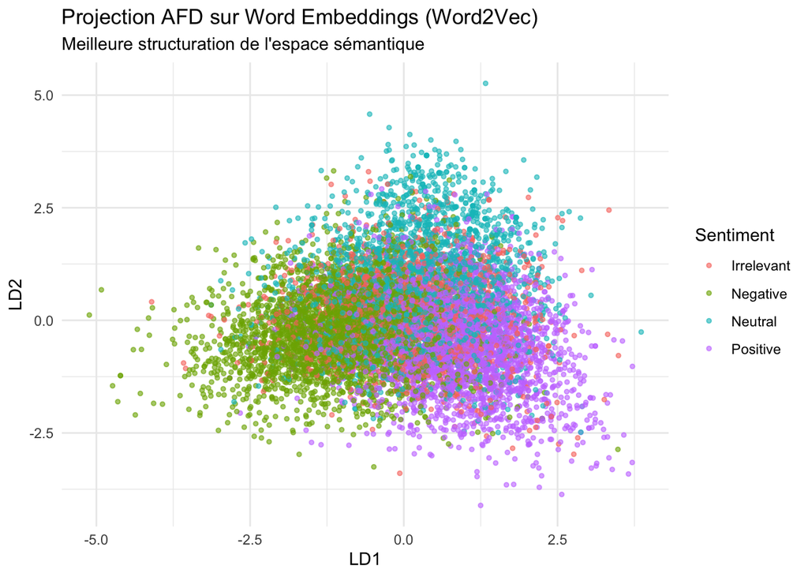

```r
# 3. Visualisation
p_lda_w2v <- predict(lda_w2v, train_vectors_w2v)
plot_w2v <- data.frame(
  LD1 = p_lda_w2v$x[,1],
  LD2 = p_lda_w2v$x[,2],
  Sentiment = train_vectors_w2v$sentiment
)

ggplot(plot_w2v, aes(x = LD1, y = LD2, color = Sentiment)) +
  geom_point(alpha = 0.6, size = 1) +
  theme_minimal() +
  labs(title = "Projection AFD sur Word Embeddings (Word2Vec)",
       subtitle = "Meilleure structuration de l'espace sémantique")
```

**Conclusion** : Les Word Embeddings offrent généralement une meilleure séparation et surtout une meilleure généralisation que l’approche TF-IDF pure, car ils “comprennent” le sens des mots au-delà de leur simple présence.

## 3.2 AFD avec Scores de Sentiment

Dans cette approche, nous utilisons des **lexiques de sentiment** pour calculer un score numérique par tweet. Contrairement aux méthodes précédentes, nous ne traitons pas les mots individuellement mais agrègeons leur “valeur émotionnelle”.

Nous utilisons trois lexiques populaires via le package `tidytext` : 1. **AFINN** : Score de -5 (très négatif) à +5 (très positif). 2. **Bing** : Classification binaire (positive/negative). 3. **NRC** : Classification en 8 émotions + positive/negative.

### 3.2.1 Calcul des Scores par Tweet

```r
# Installation du package si nécessaire
if (!require("tidytext")) install.packages("tidytext", repos = "https://cloud.r-project.org")
if (!require("textdata")) install.packages("textdata", repos = "https://cloud.r-project.org")
library(tidytext)
library(textdata)



# --- 1. Préparation des données en format tidy ---
# On tokenise chaque tweet (un mot par ligne)
train_tidy <- df_train %>%
  mutate(doc_id = row_number()) %>%
  unnest_tokens(word, text_clean)

valid_tidy <- df_valid %>%
  mutate(doc_id = row_number()) %>%
  unnest_tokens(word, text_clean)

# --- 2. Chargement des lexiques ---
# AFINN : scores numériques
afinn <- get_sentiments("afinn")

# Bing : positif/négatif binaire
bing <- get_sentiments("bing") %>%
  rename(word_sentiment = sentiment)

# NRC : émotions multiples (on garde positive/negative pour simplicité)
nrc_pn <- get_sentiments("nrc") %>%
  filter(sentiment %in% c("positive", "negative")) %>%
  rename(word_sentiment = sentiment)

# --- 3. Calcul des scores par document (Tweet) ---
# AFINN : Somme des scores des mots trouvés
train_afinn <- train_tidy %>%
  inner_join(afinn, by = "word") %>%
  group_by(doc_id) %>%
  summarise(afinn_score = sum(value, na.rm = TRUE))

valid_afinn <- valid_tidy %>%
  inner_join(afinn, by = "word") %>%
  group_by(doc_id) %>%
  summarise(afinn_score = sum(value, na.rm = TRUE))

# Bing : Compte de mots positifs - mots négatifs
train_bing <- train_tidy %>%
  inner_join(bing, by = "word") %>%
  group_by(doc_id) %>%
  summarise(
    bing_positive = sum(word_sentiment == "positive"),
    bing_negative = sum(word_sentiment == "negative"),
    bing_score = bing_positive - bing_negative
  )

valid_bing <- valid_tidy %>%
  inner_join(bing, by = "word") %>%
  group_by(doc_id) %>%
  summarise(
    bing_positive = sum(word_sentiment == "positive"),
    bing_negative = sum(word_sentiment == "negative"),
    bing_score = bing_positive - bing_negative
  )

# NRC : Compte positif - négatif
train_nrc <- train_tidy %>%
  inner_join(nrc_pn, by = "word") %>%
  group_by(doc_id) %>%
  summarise(
    nrc_positive = sum(word_sentiment == "positive"),
    nrc_negative = sum(word_sentiment == "negative"),
    nrc_score = nrc_positive - nrc_negative
  )

valid_nrc <- valid_tidy %>%
  inner_join(nrc_pn, by = "word") %>%
  group_by(doc_id) %>%
  summarise(
    nrc_positive = sum(word_sentiment == "positive"),
    nrc_negative = sum(word_sentiment == "negative"),
    nrc_score = nrc_positive - nrc_negative
  )

# --- 4. Fusion des scores avec les données originales ---
train_scores <- df_train %>%
  mutate(doc_id = row_number()) %>%
  left_join(train_afinn, by = "doc_id") %>%
  left_join(train_bing, by = "doc_id") %>%
  left_join(train_nrc, by = "doc_id") %>%
  # Remplacement des NA (mots non trouvés) par 0
  mutate(across(starts_with("afinn") | starts_with("bing") | starts_with("nrc"), ~replace_na(.x, 0)))

valid_scores <- df_valid %>%
  mutate(doc_id = row_number()) %>%
  left_join(valid_afinn, by = "doc_id") %>%
  left_join(valid_bing, by = "doc_id") %>%
  left_join(valid_nrc, by = "doc_id") %>%
  mutate(across(starts_with("afinn") | starts_with("bing") | starts_with("nrc"), ~replace_na(.x, 0)))

cat("Dimensions du dataset d'entraînement avec scores :", nrow(train_scores), "observations,",
    sum(grepl("score|positive|negative", names(train_scores))), "features de sentiment\n")
```

```
## Dimensions du dataset d'entraînement avec scores : 9788 observations, 7 features de sentiment
```

### 3.2.2 Application de l’AFD sur les Scores

Nous appliquons l’AFD sur les 7 features calculées (scores AFINN, Bing, NRC et comptes positifs/négatifs).

```r
# Préparation des données pour LDA
train_lda_scores <- train_scores %>%
  dplyr::select(sentiment, afinn_score, bing_positive, bing_negative, bing_score, nrc_positive, nrc_negative, nrc_score)

valid_lda_scores <- valid_scores %>%
  dplyr::select(sentiment, afinn_score, bing_positive, bing_negative, bing_score, nrc_positive, nrc_negative, nrc_score)

# Entraînement LDA
lda_sentiment <- lda(sentiment ~ ., data = train_lda_scores)

# Prédiction
pred_sentiment <- predict(lda_sentiment, valid_lda_scores)

# Evaluation
conf_mat_sentiment <- table(Predicted = pred_sentiment$class, Actual = valid_lda_scores$sentiment)
acc_sentiment <- sum(diag(conf_mat_sentiment)) / sum(conf_mat_sentiment)

cat("Accuracy sur le Validation Set (Scores de Sentiment + AFD) :", round(acc_sentiment * 100, 2), "%\n")
```

```
## Accuracy sur le Validation Set (Scores de Sentiment + AFD) : 45.22 %
```

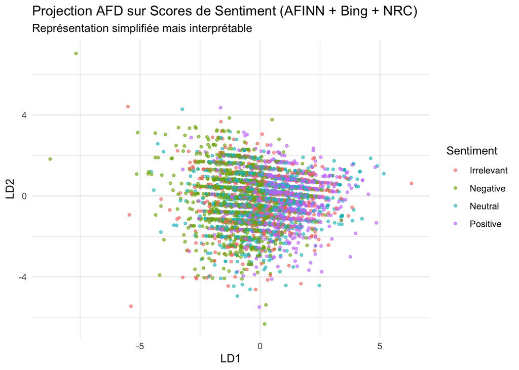

```r
# Visualisation
p_lda_sentiment <- predict(lda_sentiment, train_lda_scores)
plot_sentiment <- data.frame(
  LD1 = p_lda_sentiment$x[,1],
  LD2 = p_lda_sentiment$x[,2],
  Sentiment = train_lda_scores$sentiment
)

ggplot(plot_sentiment, aes(x = LD1, y = LD2, color = Sentiment)) +
  geom_point(alpha = 0.6, size = 1) +
  theme_minimal() +
  labs(title = "Projection AFD sur Scores de Sentiment (AFINN + Bing + NRC)",
       subtitle = "Représentation simplifiée mais interprétable")
```

**Conclusion** : Les scores de sentiment offrent une représentation très **interprétable** (on sait exactement ce que signifie chaque feature), mais ils ne capturent pas la complexité sémantique des Word Embeddings. Cette approche est souvent utilisée comme **baseline** ou pour des analyses exploratoires rapides.

# 4 Utilisation du Twitter Training Amélioré par Gemini

Cette section utilise le fichier `twitter_dataset_gemini.csv` où les labels ont été vérifiés/corrigés par l’IA Gemini.

### 4.0.1 Méthodologie de Création du Dataset “Gemini”

Pour cette section, nous introduisons une innovation majeure par rapport aux approches classiques : l’utilisation d’un **Large Language Model (LLM)** pour nettoyer et corriger les labels du dataset.

Nous avons utilisé l’API **Google Gemini 2.0 Flash** pour relire l’intégralité du dataset d’entraînement. L’objectif était double : 1. **Correction d’erreurs d’annotation** : Malgré le prétraitement, le dataset original contient de nombreuses incohérences et des labels manifestement faux (données “poorly labeled”). 2. **Affinement du sentiment** : Le modèle possède une compréhension contextuelle bien supérieure aux simples lexiques, capable de saisir l’ironie ou l’argot.

**Exemples de corrections (Tirés du dataset):**

Il est crucial de noter que le dataset d’origine contient des erreurs flagrantes que même un nettoyage syntaxique ne peut résoudre. L’IA permet de corriger sémantiquement ces cas :

| ID | Tweet | Label Humain (Original) | Correction Gemini | Analyse |
| --- | --- | --- | --- | --- |
| **1898** | “Big W.” | *Irrelevant* | **Positive** | “Big W” signifie “Big Win”, l’annotateur humain n’a pas compris l’argot. |
| **1779** | “The new” | *Positive* | **Irrelevant** | Phrase tronquée impossible à classifier, le label positif est arbitraire. |
| **2637** | “@Borderlands” | *Negative* | **Irrelevant** | Une simple mention sans aucun sentiment, classée négative à tort. |

**Protocole Technique :** * **Modèle** : `gemini-2.0-flash` * **Prompting** : Nous avons demandé au modèle d’agir en tant qu’expert en analyse de sentiment et de classifier chaque tweet en *Positive*, *Negative*, *Neutral* ou *Irrelevant* sans aucune explication verbeuse. * **Batching** : Traitement par lots de 30 tweets pour optimiser le débit et respecter les quotas de l’API. * **Résultat** : Un nouveau fichier `twitter_dataset_gemini.csv` où la colonne `sentiment` reflète “l’avis de l’IA” plutôt que celui des annotateurs humains originaux.

Cette démarche nous permet de tester si des données de meilleure qualité (re-labellisées par une IA performante) permettent d’améliorer la séparabilité des classes lors de l’AFD.

## 4.1 Chargement et Analyse des Données Gemini

Nous chargeons le dataset `twitter_dataset_gemini.csv` qui contient les mêmes tweets mais avec des labels corrigés par l’IA.

```r
# Fonction de nettoyage (re-définition pour éviter les erreurs de scope)
clean_text <- function(text) {
  # Minuscules
  text <- tolower(text)
  # Suppression des URLs
  text <- gsub("http\\S+|www\\.\\S+", "", text)
  # Suppression des mentions (@user)
  text <- gsub("@\\w+", "", text)
  # Suppression des caractères non-alphanumériques (sauf espaces)
  text <- gsub("[^a-z0-9 ]", " ", text)
  # Suppression des espaces multiples
  text <- gsub("\\s+", " ", text)
  # Trim
  text <- trimws(text)
  return(text)
}

# Chargement
gemini_file <- "../data/twitter_dataset_gemini.csv"
if(file.exists(gemini_file)) {
  gemini_data <- read.csv(gemini_file, stringsAsFactors = FALSE)

  # Nettoyage initial (idem que pour le dataset classique)
  gemini_clean <- gemini_data %>%
    filter(!is.na(text)) %>%
    filter(text != "") %>%
    # On garde les colonnes pertinentes et on renomme pour uniformiser
    dplyr::select(id, sentiment = llm_sentiment, text) %>%
    # Suppression des lignes où le sentiment est vide ou NA
    filter(!is.na(sentiment), sentiment != "") %>%
    # Suppression des URLs, mentions, etc. (fonction clean_text définie plus haut)
    mutate(text_clean = sapply(text, clean_text)) %>%
    filter(text_clean != "") %>%
    # Dédoublonnage par ID (crucial)
    distinct(id, .keep_all = TRUE)

  cat("Dataset Gemini chargé :", nrow(gemini_clean), "tweets uniques.\n")

  # Distribution des classes
  print(table(gemini_clean$sentiment))
} else {
  cat("Fichier Gemini non trouvé :", gemini_file, "\n")
}
```

```
## Dataset Gemini chargé : 12199 tweets uniques.
##
## Irrelevant   Negative    Neutral   Positive
##        522       4192       3042       4443
```